# SDM Tutorial

Elliott Hazen - adapted from code from Ben Best

Feb 20, 2020

This R Markdown file will walk you through environmentally sampled presences and absences and through options of model fitting using boosted regression trees and generalized additive mixed models.

# Introduction

In this exercise, you’ll predict the distribution of a species using the software packages [dismo](https://cran.r-project.org/web/packages/dismo/index.html) and [mgcv](https://cran.r-project.org/web/packages/mgcv/index.html) – two statistical techniques used to fit models differentiating species observations from the background environmental data. For more info on each you can visit the package homepages. Instead of using actual data, we will use “presence” points from simulated correlated walks derived from actual tag data, and background samples to simulate absences. The reason for this is just to avoid proprietary datasets in this example. We have already sampled the environmental data for both “presences” and “absences” which is important to note if you are trying to recreate this example from scratch.

NOTE: if you are using a PC, please make sure to change the directory slashes (“/”) to windows friendly (“\”)

Here’s a figure of the overall process and we’ll be doing steps 1 - 4 (although step 2 has already been done for you and step 4 will only be a climatological point map):

[figure not shown]

# 1 Species Response Data simulated from tagged sharks on the east coast

## 1.1 Read in species presence (CRW) and absence (background samples) data

Instead of using real data in this example, I’m simulating presence data from actual disctance and turn angles using a correlated random walk. These are simulated correlated random walks from a suite of tagged sharks off the southeast US and in the Gulf of Mexico. We also used the extent of the dataset to randomly sampled background points for pseudo-absence data to allow us to test if the simulated tracks use different habitat from the actual tracks.

If you want to adapt the code down the line, you can set your working directory (`wd`) and scientific species name (`sp_scientific`) of your chosen species (*Genus species* only) in the `set_vars` R chunk below.

```r
wd = 'data/'
sp_scientific = 'tshark'
```

## 1.2 Load data from RDS files

The next R chunk fetches the pre-prepared datasets for you to model. If you are interested in the environmental data sampling, please check out [the code 3a & 3b](https://github.com/elhazen/EcoCast-SciAdv). For prediction particularly in an automated setting, see [Heather Welch’s code.](https://github.com/HeatherWelch/EcoCast_Operationalization). We will be doing a very “lite” version of this as part of the tutorial.

```r
# install packages below if don't already have them in your library
  #install.packages("rgdal")
  #install.packages("raster")
  #install.packages("dismo")
  #install.packages("adehabitatLT")
  #install.packages("maps")
  #install.packages("mapdata")
  #install.packages("maptools")
  #install.packages("mgcv")
  #install.packages("ape")
  #install.packages("ncf")
  #install.packages("ncdf4")
  #install.packages("spdep")
  #install.packages("ROCR")
  #install.packages("gbm")
  #install.packages("tidyverse")
  #install.packages("viridis")

#Load libraries
suppressPackageStartupMessages(suppressWarnings({
  #library(devtools)
  #devtools::install_github("rspatial/dismo")
  library(sp)
  library(rgdal)
  library(raster)
  library(dismo)
  library(adehabitatLT) # help(package='adehabitat') # help.search('angle',package='adehabitat')
  library(maps)       # for map.where
  library(mapdata)    # for worldHires
  library(sp)
  library(maptools)
  library(mgcv)
  library(ape)
  library(ncf)
  library(ncdf4)
  library(spdep)
  library(ROCR)
  library(gbm)
  library(tidyverse)
  library(viridis)
  #library(ggmap)
  #library(RgoogleMaps)

}))

#function to grab a random absence set for modeling purposes
removeland<-function(dataset,sp.obj){
  pt = SpatialPoints(matrix(c(dataset$lon,dataset$lat), nrow=length(dataset$lon)), proj4string=CRS("+proj=longlat +datum=WGS84"))
  place = over(pt, sp.obj)
  return(dataset[is.na(place),])
}

makedataset<-function(presence,absencedata){
  #numsims<-max(absencedata$iteration)
  datasample<-sample(absencedata$iteration)[1:length(unique(presence$ID))]
  presence$presabs<-1; absencedata$presabs<-0
  common_cols <- intersect(colnames(presence), colnames(absencedata))
    presence<-subset(presence, select = common_cols)
    absencedata<-subset(absencedata, select = common_cols)
  if(exists("spdata") && is.data.frame(get("spdata"))) rm(spdata)
  for (x in 1:length(unique(presence$ID))){
    inddata<-rbind(presence[which(presence$ID==unique(presence$ID)[x]),],absencedata[absencedata$ID==unique(presence$ID)[x]&absencedata$iteration==datasample[x],])
    if(exists("spdata") && is.data.frame(get("spdata"))) spdata<-rbind(spdata,inddata) else spdata<-inddata
  }

  return(spdata)
}

saveAUC <- function(truth, predicted, ...){
  pred <- prediction(as.vector(abs(predicted)), as.vector(truth))
  roc <- performance(pred,"tpr","fpr")
  auc <- performance(pred,"auc")
  #plot(roc, ...)
  #abline(a=0, b= 1)
  return(auc@y.values)
}

plotROC <- function(truth, predicted, ...){
  pred <- prediction(as.vector(abs(predicted)), as.vector(truth))
  roc <- performance(pred,"tpr","fpr")
  auc <- performance(pred,"auc")
  plot(roc, ...)
  abline(a=0, b= 1)
  print(auc@y.values)
}


# set working directory
#setwd(wd)
dir.create('spp', showWarnings=F)
# set variables
sp_nospace = str_replace(sp_scientific, ' ', '_')

tsharkabsCRW<-readRDS(file="data/tsharkabsCRW.RDS")
tsharkabsbackgrnd<-readRDS(file="data/tsharkabsbackgrnd.RDS")
```

## 1.3 Filter by Bounding Box (interactive - NOT WORKING)

If you want to explore a subset of the data, you can restrict observations to your area of interest. To do this, you’re provided with an interactive map to draw a bounding box extent around the points of interest.

For the interactive drawing to work, you’ll want to go to upper right RStudio menu Chunks -> Run All so the R code is run from the Console. *(Note: Knitting the R Markdown document is not interactive.)*

The bounding box extent is saved to `spp/*_extent.csv` which is read in next time the code runs. (The interactive drawing of bounding box is presented if the file’s not found, or defaults to global extent if not run interactively.).

```
## NOTE: Not filtering original points for extent because file 'spp/tshark_extent.csv' not found
```

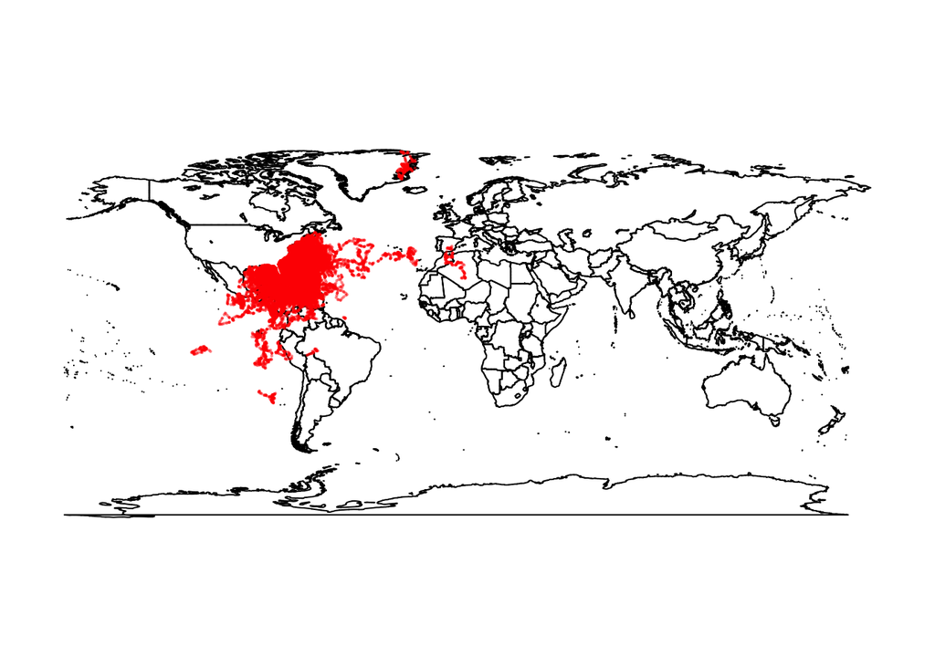

```r
# vars
csv_extent = sprintf('spp/%s_extent.csv', sp_nospace)
do_extent  = F

#  for google map background...
  #mymapkey = "pk-tHVbDiymfUL"
  #mygeokey = "Skxe99-adfKeax"

#  register_google(key = key)
#map <- get_map(extent(pts_tshark_pres)[1:4])
#ggmap(map, xlim=extent(pts_tshark_pres)[1:2], ylim=extent(pts_tshark_pres)[3:4])
#ggmap(map) +
#  geom_point(aes(x = lon, y = lat, colour = Year), data = tsharkabsCRW, alpha = .5)

# plot map of original shark points
pts_tshark_pres = tsharkabsCRW
coordinates(pts_tshark_pres) = ~lon+lat
#map_gbif = readRDS("data/globalmap.RDS")
#map_background = maps::map('worldHires', xlim=extent(pts_tshark_pres)[1:2], ylim=extent(pts_tshark_pres)[3:4])

map_background = maps::map('worldHires', fill=T, col='transparent')
back.IDs = sapply(strsplit(map_background$names, ":"), function(x) x[1])
back.sp = map2SpatialPolygons(map_background, IDs=back.IDs, proj4string=CRS("+proj=longlat +datum=WGS84"))


#plot(map_gbif)
points(pts_tshark_pres, pch=16, col=rgb(1, 0, 0, alpha=0.5), cex=0.3)


# if (interactive() & !file.exists(csv_extent)){
#   cat(paste(
#     "You're encouraged to explore limiting the points to a region of interest. ",
#     "In the map plot, please click on the two opposite corners ",
#     "of a bounding box for filtering to use only observation points",
#     "within the box.\n", sep='\n'))
#   extent_filter = drawExtent()
#   print(extent_filter)
#   write.csv(as.matrix(extent_filter), csv_extent, row.names=F)
#   do_extent = T
# }

if (file.exists(csv_extent)){
  extent_filter = extent(as.vector(t(read.csv(csv_extent))))
  plot(extent_filter, col='red', add=T)
} else {
  # default to global
  extent_filter = extent(-120, 100, 10, 80)
  cat(sprintf(paste(
    "NOTE: Not filtering original points for extent",
    "because file '%s/%s' not found"),
    dirname(csv_extent), basename(csv_extent)))
}
```

Note how many points are in strange locations (e.g. on land!). This is something to be aware of and potentially filter (we will) down the line.

# 2 Run the GAMM

GAMs are an extension of *generalized linear models*. In GAMs the linear predictor is the sum of the smoothing functions, which makes them very flexible and able to handle complex non-linear relationships between species response and environmental predictors.

## 2.1 Partition Points into Training and Test (automatic)

A common method to evaluate the fit of a model is **cross-validation**. In this approach you create a model with one *training* data set and then *testing* occurs using another data set of known occurences. Typically the test and training data sets are created through random sampling (without replacement) from a single data set. We will walk through a full 100% model (only training data) and how this looks different from the 80%/20% model. After exploring these two, our example continues ahead with the 100% model for prediction but it would be easy (and feel free to explore) using the 80% model in the prediction chunk below.

The next R chunk:

1. combines a random subset of presence and absence datapoints
2. Filters the observation points based on the extent from the previous step, and
3. Partitions these points randomly into:
1. **train** for model fitting (80% of filtered points), and
2. **test** for model evaluation (20%).
4. Plots train (red) and test (blue) points onto a map (see below).

This exercise is used in the GAMM code below but has not yet been split for the BRTs simply due to time. If you are brave, try creating your own code chunk that calculates AUC from BRT test and training data.

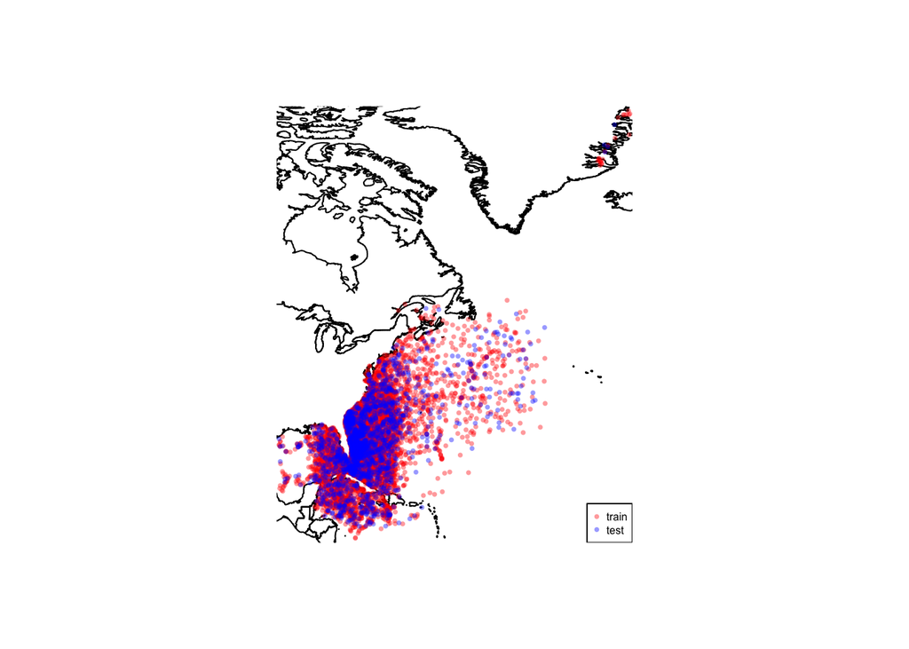

```r
# vars
#tsharkabsCRW<-readRDS(file="./Data/tsharkabsCRW.RDS")
#tsharkabsbackgrnd<-readRDS(file="./Data/tsharkabsbackgrnd.RDS")

tsharkabsbackgrnd$lon<-tsharkabsbackgrnd$long
sharkdata<-makedataset(tsharkabsCRW[tsharkabsCRW$iteration==1,],tsharkabsbackgrnd)

#get rid of those pesky points on land
sharkdata<-removeland(sharkdata,back.sp)

csv_train  = sprintf('spp/%s_train.csv' , sp_nospace)
csv_test   = sprintf('spp/%s_test.csv'  , sp_nospace)
if ((!file.exists(csv_train) | !file.exists(csv_test)) | do_extent){

  # get columns used, filter based on drawn extent
  e = as.matrix(extent_filter)
  d = sharkdata %>%
    filter(
      lon > e['x','min'],
      lon < e['x','max'],
      lat > e['y','min'],
      lat < e['y','max'])

  # for modeling, withold 20% sample for testing
  fold = kfold(d, k=5)
  write.csv(d[fold==1, ], csv_test, row.names=F, na='')
  write.csv(d[fold!=1, ], csv_train, row.names=F, na='')
}
# read in test and train data
d = rbind(
  read.csv(csv_test) %>%
    mutate(partition='test'),
  read.csv(csv_train) %>%
    mutate(partition='train'))
# plot map of test and train pts
pts = d
coordinates(pts) = ~lon+lat
#map_pts <- gmap(pts, lonlat=T)
#plot(map_pts)
map_pts = maps::map('worldHires', fill=T, col='transparent',xlim=extent(pts)[1:2], ylim=extent(pts)[3:4])
#plot(map_background)
points(pts %>% subset(partition=='train'),
       pch=16, col=rgb(1, 0, 0, alpha=0.4), cex=0.5)
points(pts %>% subset(partition=='test') ,
       pch=16, col=rgb(0, 0, 1, alpha=0.4), cex=0.5)
legend('bottomright', c('train','test'),
       pch=16, col=c(rgb(1, 0, 0, alpha=0.4), rgb(0, 0, 1, alpha=0.4)), cex=0.5)
```

**Question**: Is 80 / 20% the best way to train / test the data? What issues might arise from this approach?

## 2.2 Fit the GAMM

Now that you have your biological response test and training data (in `spp` folder) with environmental predictor data already sampled, you’re ready to fit, predict and evaluate a species distribution model. Environmental predictors for this example are:

1. SST - sea surface temperature
2. SST_SD - standard deviation of sea surface temperature
3. MLD - mixed layer depth from a global model
4. Oxygen_100m - climatological oxygen from a global model
5. Theta_max - a metric of frontal structure using FTLE (Finite Time Lyapunov Exponents)
6. log10(Chla_4km_8day) - 8day averaged chlorophyll from a blended product
7. log10(Chla_25km_monthly+0.001) - monthly averaged chlorophyll from a blended product
8. SSH - sea surface height anomaly from long term mean
9. SLA - sea level anomaly above the geoid
10. Bathymetry - bottom depth in meters
11. Rugosity - bottom roughness in meters

The first GAMM example is a full model and you’ll see that the model does not converge. Instead, try running the second model to see what factors are significant. This is also a chance to modify the variables and explore the model fitting process. This code also exports some basic model statistics:

[AIC](https://en.wikipedia.org/wiki/Akaike_information_criterion) - a metric of model fit penalized by the complexity of the model. It allows model comparison.

[AUC](https://towardsdatascience.com/understanding-auc-roc-curve-68b2303cc9c5?gi=bf72558fa345) Area Under the Curve statistic. A value of 1 is a perfect model, while a value of 0.5 is a random model. High AUC indicates that sites with high predicted suitability values tend to be areas of known presence and areas of lower predicted suitability values tend to be areas where species are not known to occur. There are issues with AUC as highly zero-inflated data can give high AUC values even if it is incorrectly predicting the presences. It is calculated from the receiver-operating curve (ROC) which is the final plot. The ROC is important to understand the rate of false positives (1 - specificity on the x-axis) and true positives (sensitivity on the y-axis).

The summary plot gives you individual variable statistics including significance and overall model R2.

GAMcheck creates plots to explore data normalcy.

We also plot the response curves to see which variables have the greatest contribution to the final model.

```r
# Start with all environmental variables. What happens?

try(tsharkGAMM<-gamm(presabs~s(SST,bs="ts",k=5)+s(SST_SD,bs="ts",k=5)+s(MLD,bs="ts",k=5)+s(Oxygen_100m,bs="ts",k=5)+s(Theta_max,bs="ts", k=5)+s(log10(Chla_4km_8day+0.001),k=5,bs="ts")+s(log10(Chla_25km_monthly+0.001),k=5,bs="ts")+s(SSH,k=5,bs="ts")+s(SLA,k=5,bs="ts")+s(Bathymetry,k=5,bs="ts")+s(Rugosity,k=5,bs="ts"), random=list(ID=~1),family=binomial, niterPQL=50, data=na.omit(sharkdata)))
```

```
## iteration 1
```

```
## iteration 2
```

```
## iteration 3
```

```
## iteration 4
```

```
## iteration 5
```

```r
###switch to a reduced model. Feel free to pick your variables of interest from here-on out.
tsharkGAMM<-gamm(presabs~s(SST,bs="ts", k=5)+s(log10(Chla_25km_monthly+0.001),bs="ts", k=5)+s(SLA,bs="ts", k=5)+s(Bathymetry,bs="ts", k=5), random=list(ID=~1),family=binomial, niterPQL=50, data=na.omit(sharkdata)) #get(paste("GAMdataRun",l,sep=''))
```

```
## iteration 1
## iteration 2
```

```
## iteration 3
```

```
## iteration 4
```

```
## iteration 5
```

This GAMcheck shows you whether your data going into the model are normal. The summary table below is a test of whether the basis dimension for a smooth is adequate (Wood, 2017, section 5.9) and the further below 1 this is, the more likely it is that there is missed pattern left in the residuals. The p-value is computed by simulation.

From the [documentation](https://www.rdocumentation.org/packages/mgcv/versions/1.8-31/topics/gam.check), take care when interpreting results from applying this function to a model fitted using gamm. In this case the returned gam object is based on the working model used for estimation, and will treat all the random effects as part of the error. This means that the residuals extracted from the gam object are not standardized for the family used or for the random effects or correlation structure. Usually it is necessary to produce your own residual checks based on consideration of the model structure you have used.

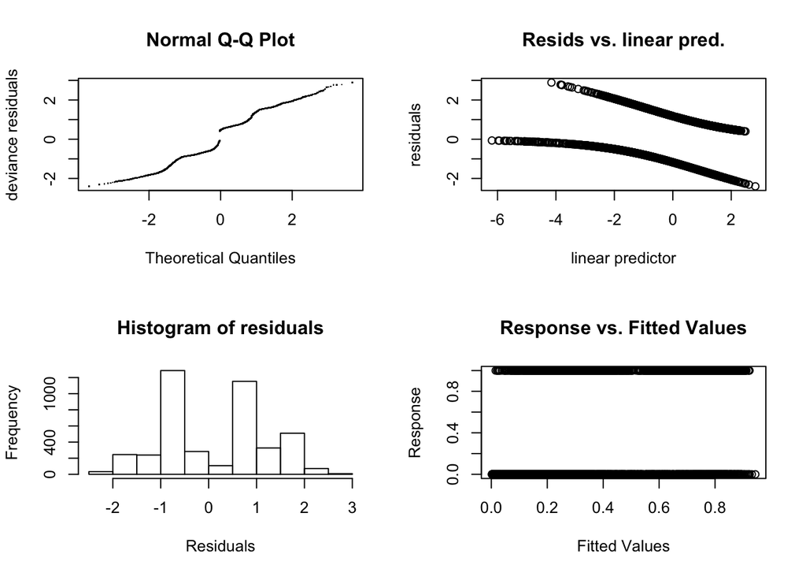

```
##
## 'gamm' based fit - care required with interpretation.
## Checks based on working residuals may be misleading.
## Basis dimension (k) checking results. Low p-value (k-index<1) may
## indicate that k is too low, especially if edf is close to k'.
##
##                                          k'     edf k-index p-value
## s(SST)                              4.00000 3.57422    0.99    0.41
## s(log10(Chla_25km_monthly + 0.001)) 4.00000 0.00127    0.84  <2e-16 ***
## s(SLA)                              4.00000 3.35460    0.99    0.47
## s(Bathymetry)                       4.00000 3.85994    0.94  <2e-16 ***
## ---
## Signif. codes:  0 '***' 0.001 '**' 0.01 '*' 0.05 '.' 0.1 ' ' 1
```

```r
par(mfrow=c(2,2))
gam.check(tsharkGAMM$gam)
```

**Question:** Why do two of the gam_check plots look so strange?

```r
print(paste0("AIC value is: ", AIC(tsharkGAMM$lme)))
```

```
## [1] "AIC value is: 20698.0153389595"
```

```r
print("Summary statistics for the GAMM:")
```

```
## [1] "Summary statistics for the GAMM:"
```

```r
print(summary(tsharkGAMM$gam))
```

```
##
## Family: binomial
## Link function: logit
##
## Formula:
## presabs ~ s(SST, bs = "ts", k = 5) + s(log10(Chla_25km_monthly +
##     0.001), bs = "ts", k = 5) + s(SLA, bs = "ts", k = 5) + s(Bathymetry,
##     bs = "ts", k = 5)
##
## Parametric coefficients:
##             Estimate Std. Error t value Pr(>|t|)
## (Intercept)  -0.2623     0.1335  -1.965   0.0495 *
## ---
## Signif. codes:  0 '***' 0.001 '**' 0.01 '*' 0.05 '.' 0.1 ' ' 1
##
## Approximate significance of smooth terms:
##                                          edf Ref.df      F p-value
## s(SST)                              3.574220      4  18.89  <2e-16 ***
## s(log10(Chla_25km_monthly + 0.001)) 0.001269      4   0.00   0.533
## s(SLA)                              3.354601      4  21.25  <2e-16 ***
## s(Bathymetry)                       3.859941      4 164.29  <2e-16 ***
## ---
## Signif. codes:  0 '***' 0.001 '**' 0.01 '*' 0.05 '.' 0.1 ' ' 1
##
## R-sq.(adj) =  0.223
##   Scale est. = 1         n = 4264
```

```r
print("GAMM response curves:")
```

```
## [1] "GAMM response curves:"
```

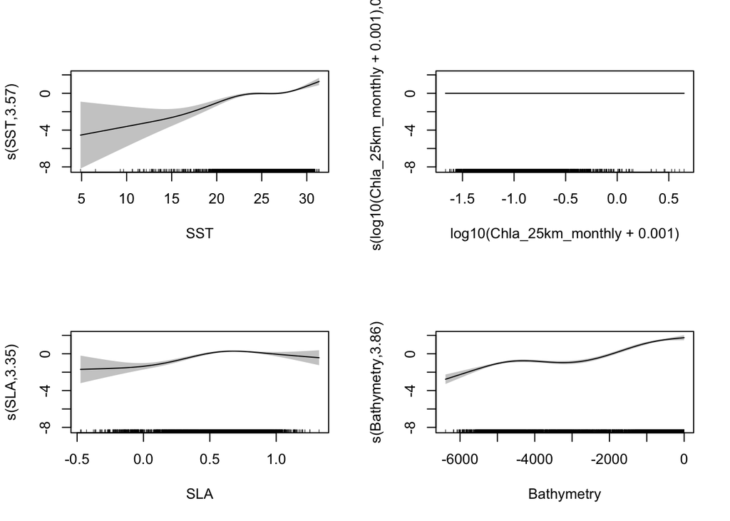

```r
par(mfrow=c(2,2))
plot(tsharkGAMM$gam, shade=TRUE)
```

```r
newdata<-predict.gam(tsharkGAMM$gam, sharkdata,se=TRUE, type="response")
newdata$presabs <- sharkdata$presabs
print(paste0("AUC value is: ", saveAUC(newdata$presabs,newdata$fit)))
```

```
## [1] "AUC value is: 0.720358854413987"
```

```r
#print(saveAUC(newdata$presabs,newdata$fit))
print("Reciever operator curve:")
```

```
## [1] "Reciever operator curve:"
```

```r
plotROC(newdata$presabs,newdata$fit, colorize = TRUE)
```

```
## [[1]]
## [1] 0.7203589
```

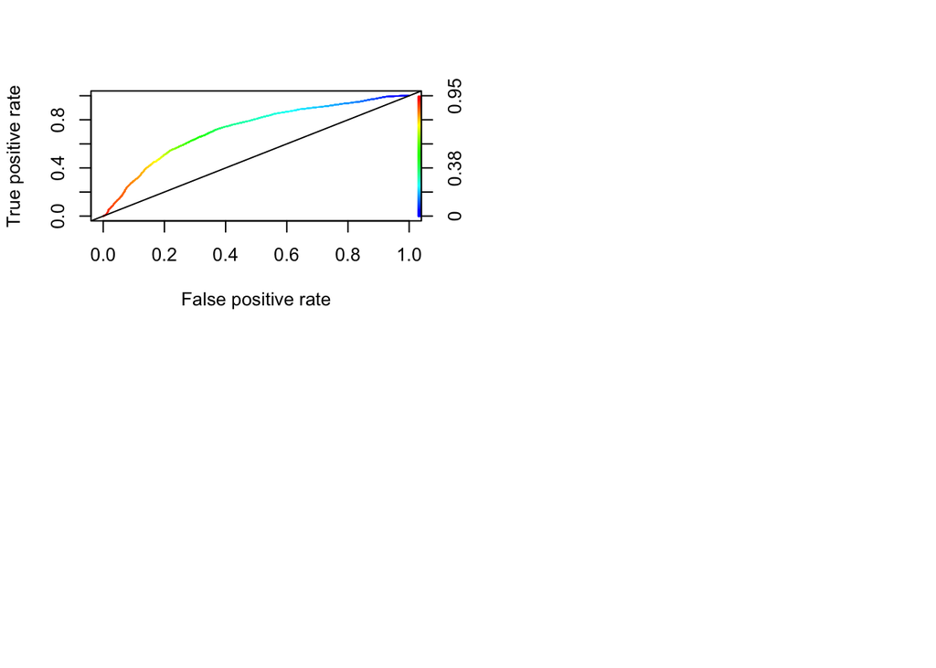

```r
GAMpredict<-cbind(sharkdata,newdata$fit)

saveRDS(tsharkGAMM, file="spp/bestGAMMmodel.RDS")
```

## 2.3 GAMM fit on train, predict on test

```r
train <- d  %>%
    filter(partition=='train')
test <- d  %>%
    filter(partition=='test')

###starting with the reduced model but predicting on test data
tsharkGAMM<-gamm(presabs~s(SST,bs="ts", k=5)+s(log10(Chla_25km_monthly+0.001),bs="ts", k=5)+s(SLA,bs="ts", k=5)+s(Bathymetry,bs="ts", k=5), random=list(ID=~1),family=binomial, niterPQL=100, data=na.omit(train)) #get(paste("GAMdataRun",l,sep=''))
```

```
## iteration 1
```

```
## iteration 2
```

```
## iteration 3
```

```
## iteration 4
```

```
## iteration 5
```

```
## iteration 6
```

```
## iteration 7
```

```
## iteration 8
```

```
## iteration 9
```

```
## iteration 10
```

```
## iteration 11
```

```
## iteration 12
```

Model evaluation statistics are below. These are only a subset of what I would recommend exploring but AIC is a metric of model fit (comparison among models), while AUC is a metric of model skill (0.5 ~ random, 1.0 perfect positive predictions). The ROC is useful for visualizing the AUC score.

```r
print(paste0("AIC value for training data is: ", AIC(tsharkGAMM$lme)))
```

```
## [1] "AIC value for training data is: 16812.3819154546"
```

```r
#print(AIC(tsharkGAMM$lme))
print("Summary statistics for the training GAMM:")
```

```
## [1] "Summary statistics for the training GAMM:"
```

```r
print(summary(tsharkGAMM$gam))
```

```
##
## Family: binomial
## Link function: logit
##
## Formula:
## presabs ~ s(SST, bs = "ts", k = 5) + s(log10(Chla_25km_monthly +
##     0.001), bs = "ts", k = 5) + s(SLA, bs = "ts", k = 5) + s(Bathymetry,
##     bs = "ts", k = 5)
##
## Parametric coefficients:
##             Estimate Std. Error t value Pr(>|t|)
## (Intercept)  -0.3043     0.1369  -2.224   0.0262 *
## ---
## Signif. codes:  0 '***' 0.001 '**' 0.01 '*' 0.05 '.' 0.1 ' ' 1
##
## Approximate significance of smooth terms:
##                                           edf Ref.df      F  p-value
## s(SST)                              3.3915220      4  13.80 9.46e-13 ***
## s(log10(Chla_25km_monthly + 0.001)) 0.0004323      4   0.00    0.201
## s(SLA)                              3.1994604      4  26.41  < 2e-16 ***
## s(Bathymetry)                       3.7151777      4 139.46  < 2e-16 ***
## ---
## Signif. codes:  0 '***' 0.001 '**' 0.01 '*' 0.05 '.' 0.1 ' ' 1
##
## R-sq.(adj) =  0.236
##   Scale est. = 1         n = 3448
```

```r
newdata<-predict.gam(tsharkGAMM$gam, test, se=TRUE, type="response")
newdata$presabs <- test$presabs
print(paste0("AUC value for GAMM on test data is: ", saveAUC(newdata$presabs,newdata$fit)))
```

```
## [1] "AUC value for GAMM on test data is: 0.738495056058084"
```

```r
#print(saveAUC(newdata$presabs,newdata$fit))
print("Reciever operator curve:")
```

```
## [1] "Reciever operator curve:"
```

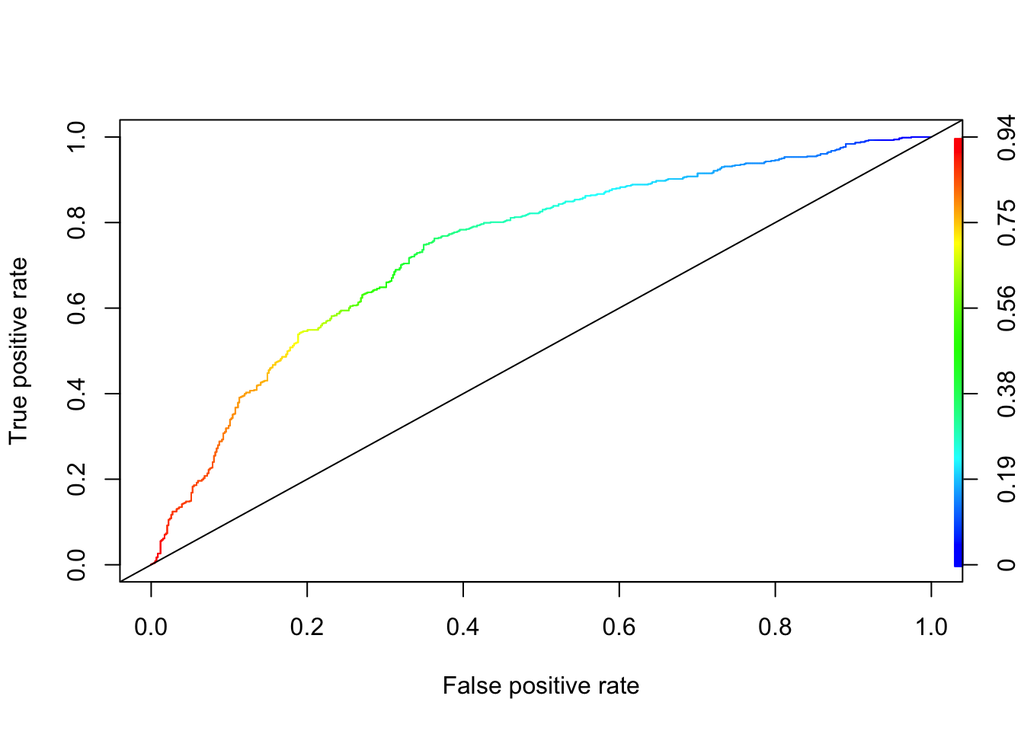

```
## [[1]]
## [1] 0.7384951
```

```r
plotROC(newdata$presabs,newdata$fit, colorize = TRUE)
```

# 3 Run Boosted Regression Trees (BRTs)

The text below is stolen directly from [Elith et al. 2008](https://besjournals.onlinelibrary.wiley.com/doi/full/10.1111/j.1365-2656.2008.01390.x):

BRT is one of several techniques that aim to improve the performance of a single model by fitting many models and combining them for prediction. BRT uses two algorithms: regression trees are from the classification and regression tree (decision tree) group of models, and boosting builds and combines a collection of models. We deal with each of these components in turn.

Number of trees vs. learning rate (lr) The lr is used to shrink the contribution of each tree as it is added to the model. Decreasing (slowing) lr increases the number of trees required, and in general a smaller lr (and larger nt) are preferable, conditional on the number of observations and time available for computation. The usual approach is to estimate optimal nt and lr with an independent test set or with CV, using deviance reduction as the measure of success. The following analysis demonstrates how performance varies with these parameters using a subsample of the data set for model fitting, and the remaining data for independent evaluation.

Bag fraction is the proportion of data to use in fitting (75% in the example below) with 25% held back for testing.

## 3.1 Fit a BRT model

```r
# Start with all environmental variables. What happens?

try(tsharkBRT.lr005.CRW<-gbm.fixed(data=sharkdata,gbm.x=8:22, gbm.y=24, family="bernoulli",tree.complexity=5, learning.rate = 0.005, n.trees = 2000, bag.fraction=0.75))
```

```
## [1] fitting gbm model with a fixed number of 2000 trees for presabs
## [1] total deviance = 11979.01
## [1] residual deviance = 8474.74
```

```r
BRTmodel <- tsharkBRT.lr005.CRW
```

Here we used gbm.fixed to build the BRT model. This allows us to fit a model of a set number of trees (nt). Alternatively, you could use gbm.step, which doesn’t specify the number of trees, but autmatically finds the optimal nt given the desired lr. Elith et al. (2008) provides a rules of thumb which can help determine a good starting point for lr and nt.

## 3.2 BRT Model Evaluation and Prediction

We will use the same environmental variables and AUC as an evaluation metric here as well. This does not calculate the 80/20 as we did above for GAMMs but you could do that on your own if you are interested.

```r
print("Summary statistics for the full BRT:")
```

```
## [1] "Summary statistics for the full BRT:"
```

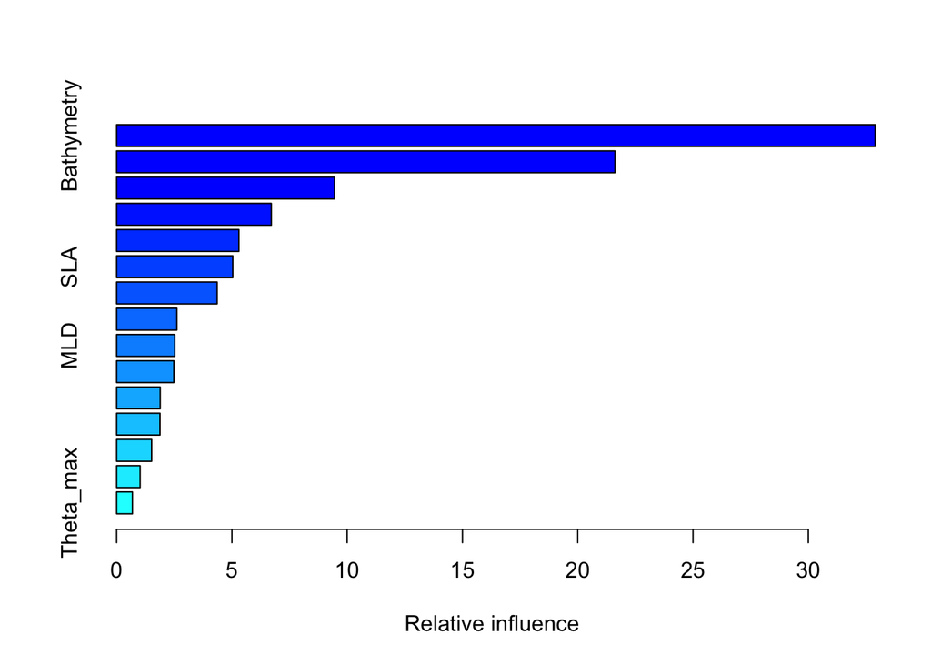

```
##                                 var    rel.inf
## Bathymetry               Bathymetry 32.9010001
## Oxygen_Surface       Oxygen_Surface 21.6145089
## Oxygen_100m             Oxygen_100m  9.4509431
## Chla_25km_monthly Chla_25km_monthly  6.7104232
## SST                             SST  5.3033990
## SLA                             SLA  5.0396040
## Rugosity                   Rugosity  4.3615963
## U                                 U  2.6143612
## MLD                             MLD  2.5219817
## Chla_4km_8day         Chla_4km_8day  2.4817204
## SST_SD                       SST_SD  1.8925156
## V                                 V  1.8814265
## SSH                             SSH  1.5194788
## FSLE_max                   FSLE_max  1.0209587
## Theta_max                 Theta_max  0.6860826
```

```r
summary(BRTmodel)
```

```r
print(paste0("AUC value for BRT full data is: ", saveAUC(sharkdata$presabs,BRTmodel$fitted)))
```

```
## [1] "AUC value for BRT full data is: 0.855469161314979"
```

```r
#AUCval<-saveAUC(sharkdata$presabs,BRTmodel$fitted)
#print(AUCval)
print("Receiver operating curve for the full BRT:")
```

```
## [1] "Receiver operating curve for the full BRT:"
```

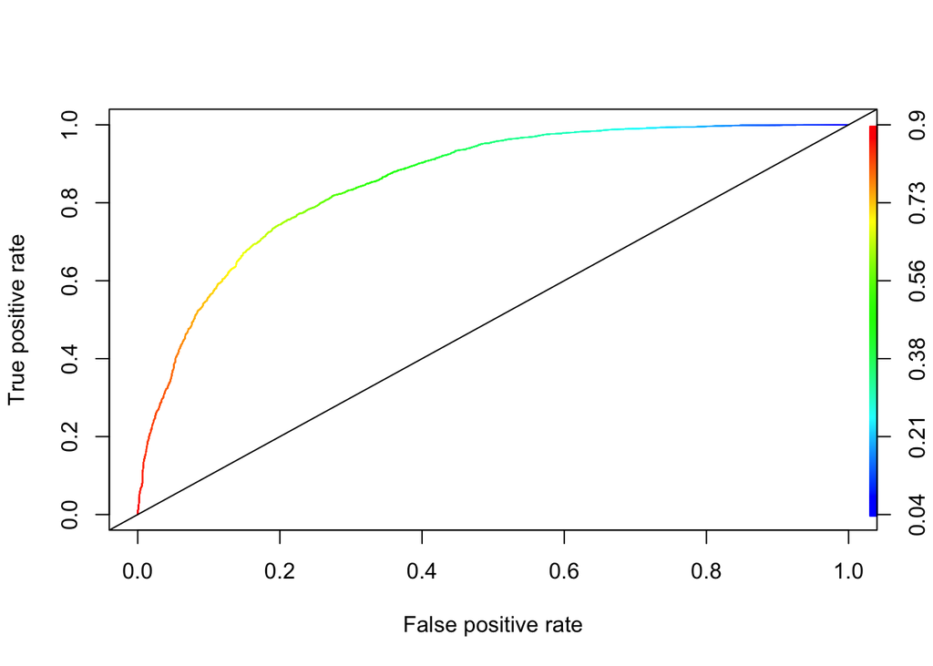

```
## [[1]]
## [1] 0.8554692
```

```r
plotROC(sharkdata$presabs,BRTmodel$fitted, colorize = TRUE)
```

```r
BRTpredict<-cbind(sharkdata,BRTmodel$fitted)

print("Partial response curves for the full BRT model:")
```

```
## [1] "Partial response curves for the full BRT model:"
```

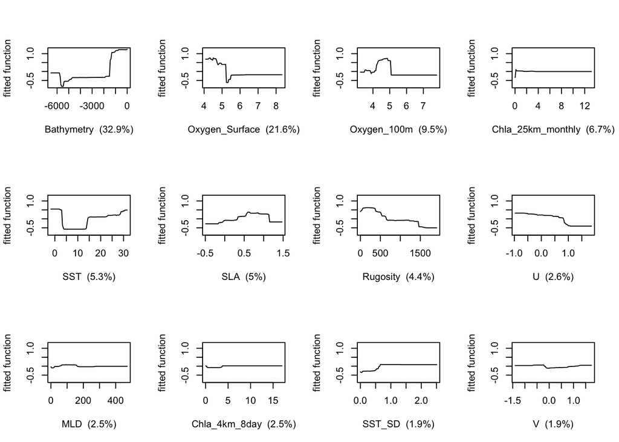

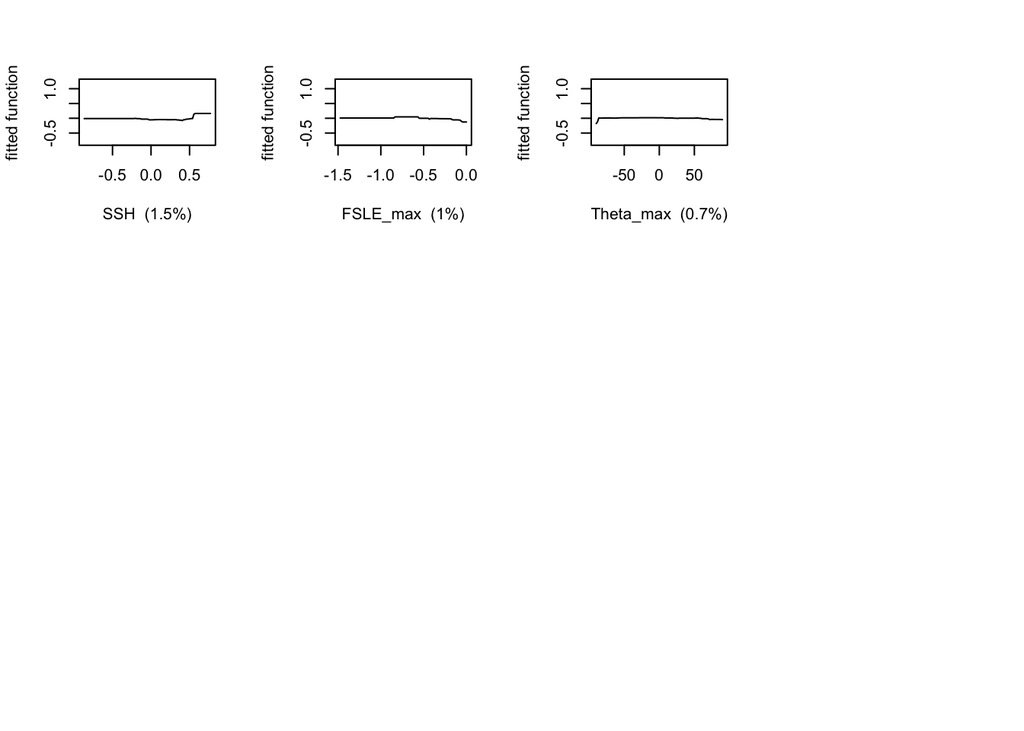

```r
par(mfrow=c(4,4))
gbm.plot(BRTmodel, write.title = FALSE)
```

```r
saveRDS(BRTmodel, file="spp/bestBRTmodel.RDS")
```

# 4 Let’s plot predictions from each model!

Ideally you would download individual environmental layers that went into your final model for the study area of interest (e.g. see [EcoCast shiny app](https://heatherwelch.shinyapps.io/ecocastapp/)) and then produce a prediction on those new data. This would give you a snapshot in time of what the model is telling you. Instead, for the sake of brevity, we are simply plotting the predictions colored by the “habitat suitability” from each model.

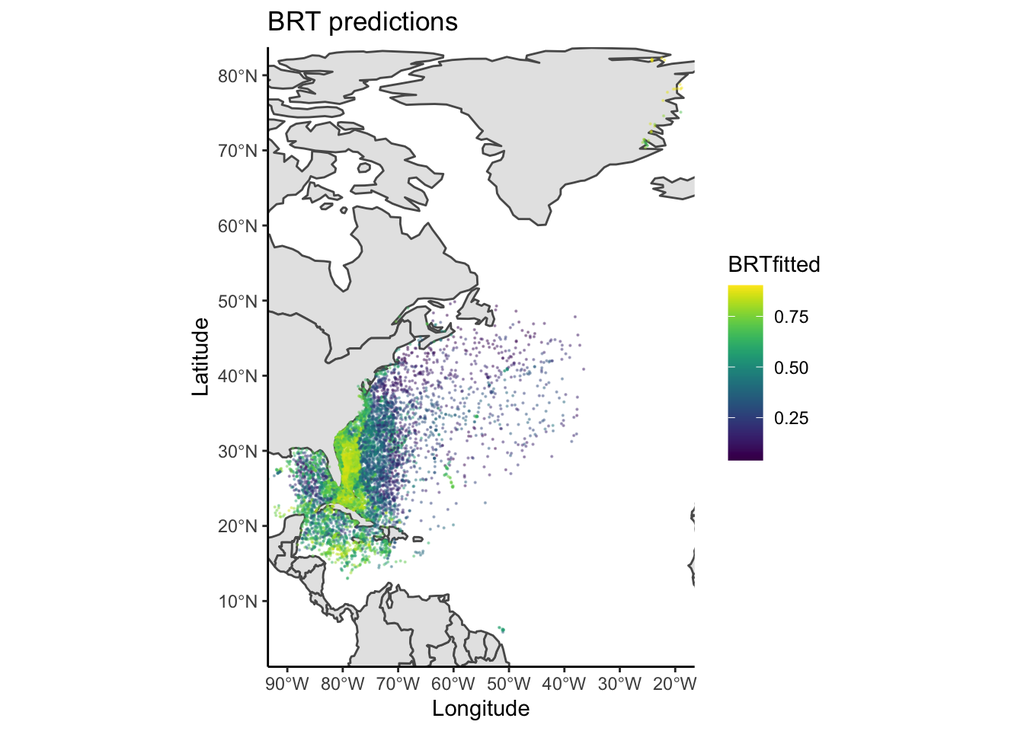

```r
names(GAMpredict)[25]<-"GAMMfitted"
names(BRTpredict)[25]<-"BRTfitted"

ggplot(data = world) +
    geom_sf() +
    theme_classic() +
    xlab("Longitude") + ylab("Latitude") +
    ggtitle("BRT predictions") +
    geom_point(data = BRTpredict, size = 0.1, alpha = 0.35, aes(x=lon, y=lat, color=BRTfitted)) +
    scale_colour_viridis() +
    coord_sf(xlim = c(-90, -20), ylim = c(5, 80))
```

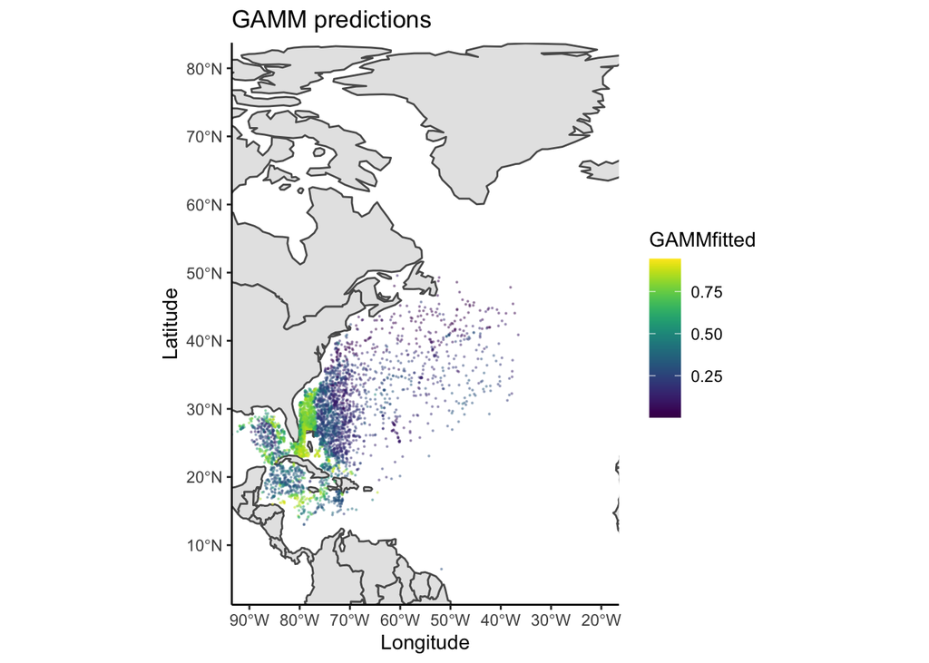

```r
ggplot(data = world) +
    geom_sf() +
    theme_classic() +
    xlab("Longitude") + ylab("Latitude") +
    ggtitle("GAMM predictions") +
    geom_point(data = na.omit(GAMpredict), size = 0.1, alpha = 0.35, aes(x=lon, y=lat, color=GAMMfitted)) +
    scale_colour_viridis() +
    coord_sf(xlim = c(-90, -20), ylim = c(5, 80))
```

**Question:** What are the biggest differences between the prediction plots for both models? Any idea why?

# Further Resources

A 2006 [comparison](https://onlinelibrary.wiley.com/doi/full/10.1111/j.2006.0906-7590.04596.x) of modeling approaches, and further [a 2019 consideration](https://people.ucsc.edu/~elhazen/hazen/Publications_files/Brodie_et_al-2019-Ecography.pdf) for co-variate selection and climate projections.

Boosted regression trees [for ecological modeling](http://cran.fhcrc.org/web/packages/dismo/vignettes/brt.pdf) and a [working guide](https://besjournals.onlinelibrary.wiley.com/doi/full/10.1111/j.1365-2656.2008.01390.x)

[MGCV](https://cran.r-project.org/web/packages/mgcv/mgcv.pdf) and an introduction to [Generalized Additive Mixed Models](https://highstat.com/index.php/beginner-s-guide-to-generalized-additive-mixed-models) - but see [gamm4](https://cran.r-project.org/web/packages/gamm4/gamm4.pdf) as an alternative package.

Ben Best’s [course](https://github.com/bbest/landscape-ecology-labs) on landscape ecology and a [thorough tutorial](https://rspatial.org/raster/sdm/index.html) on species distributional modeling and spatial data more generally.